# Assignment 3: Visual Perception

## Import the required libraries

```python
import pandas as pd
from matplotlib import pyplot as plt
import warnings
warnings.filterwarnings('ignore')
%matplotlib inline
```

## Install the vega-datasets package

```python
pip install vega-datasets
```

## Check the datasets available in the vega-datasets package

```python
from vega_datasets import data


datasets=data.list_datasets()
print(datasets)
print(f"\nThe number of available datasets is: {len(datasets)} ")
```

```
['7zip', 'airports', 'annual-precip', 'anscombe', 'barley', 'birdstrikes', 'budget', 'budgets', 'burtin', 'cars', 'climate', 'co2-concentration', 'countries', 'crimea', 'disasters', 'driving', 'earthquakes', 'ffox', 'flare', 'flare-dependencies', 'flights-10k', 'flights-200k', 'flights-20k', 'flight…

The number of available datasets is: 70
```

## Check the local datasets available in the vega-datsets package

```python
from vega_datasets import local_data
local_datasets=local_data.list_datasets()
print(local_datasets)
print(f"\nThe number of local_datasets available is: {len(local_datasets)} ")
```

```
['airports', 'anscombe', 'barley', 'burtin', 'cars', 'crimea', 'driving', 'iowa-electricity', 'iris', 'la-riots', 'ohlc', 'seattle-temps', 'seattle-weather', 'sf-temps', 'stocks', 'us-employment', 'wheat']

The number of local_datasets available is: 17
```

Lets first work with the famous Anscombe quartet dataset.

*According to Wikipedia, "Anscombe's quartet comprises four data sets that have nearly identical simple descriptive statistics, yet have very different distributions and appear very different when graphed. Each dataset consists of eleven (x,y) points. They were constructed in 1973 by the statistician Francis Anscombe to demonstrate both the importance of graphing data before analyzing it and the effect of outliers and other influential observations on statistical properties. He described the article as being intended to counter the impression among statisticians that "numerical calculations are exact, but graphs are rough."*

We can also check the description of the dataset description using the following command-

```python
local_data.anscombe.description
```

```
"Anscombe's Quartet is a famous dataset constructed by Francis Anscombe [1]_. Common summary statistics are identical for each subset of the data, despite the subsets having vastly different characteristics."
```

Now lets analyze and plot the anscombe dataset-

```python
df=local_data.anscombe()
```

Lets peek the head of the dataset-

```python
df.head()
```

|  | Series | X | Y |
| --- | --- | --- | --- |
| 0 | I | 10 | 8.04 |
| 1 | I | 8 | 6.95 |
| 2 | I | 13 | 7.58 |
| 3 | I | 9 | 8.81 |
| 4 | I | 11 | 8.33 |

Lets peek the tail-

```python
df.tail()
```

|  | Series | X | Y |
| --- | --- | --- | --- |
| 39 | IV | 8 | 5.25 |
| 40 | IV | 19 | 12.50 |
| 41 | IV | 8 | 5.56 |
| 42 | IV | 8 | 7.91 |
| 43 | IV | 8 | 6.89 |

**Task 1:** Draw a scatterplot of the dataset "I" in the anscombe quartet.

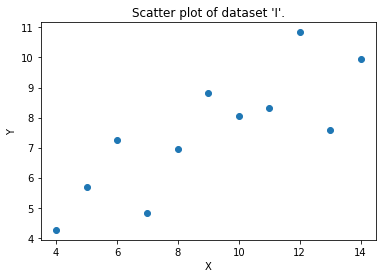

```python
x=df[df['Series']=='I'].X # Filter and extract the x-coordinates of points in dataset "I".
y=df[df['Series']=='I'].Y # Filter and extract the y-coordinates of points in dataset "I".

plt.scatter(x,y);
plt.xlabel('X');
plt.ylabel('Y');
plt.title("Scatter plot of dataset 'I'.");
```

## Plotting cars characteristics

Now lets examine another dataset. This time it's about cars

```python
car_df=local_data.cars()
car_df.head()
```

|  | Name | Miles_per_Gallon | Cylinders | Displacement | Horsepower | Weight_in_lbs | Acceleration | Year | Origin |
| --- | --- | --- | --- | --- | --- | --- | --- | --- | --- |
| 0 | chevrolet chevelle malibu | 18.0 | 8 | 307.0 | 130.0 | 3504 | 12.0 | 1970-01-01 | USA |
| 1 | buick skylark 320 | 15.0 | 8 | 350.0 | 165.0 | 3693 | 11.5 | 1970-01-01 | USA |
| 2 | plymouth satellite | 18.0 | 8 | 318.0 | 150.0 | 3436 | 11.0 | 1970-01-01 | USA |
| 3 | amc rebel sst | 16.0 | 8 | 304.0 | 150.0 | 3433 | 12.0 | 1970-01-01 | USA |
| 4 | ford torino | 17.0 | 8 | 302.0 | 140.0 | 3449 | 10.5 | 1970-01-01 | USA |

Summary statistics:

```python
car_df.describe()
```

|  | Miles_per_Gallon | Cylinders | Displacement | Horsepower | Weight_in_lbs | Acceleration |
| --- | --- | --- | --- | --- | --- | --- |
| count | 398.000000 | 406.000000 | 406.000000 | 400.000000 | 406.000000 | 406.000000 |
| mean | 23.514573 | 5.475369 | 194.779557 | 105.082500 | 2979.413793 | 15.519704 |
| std | 7.815984 | 1.712160 | 104.922458 | 38.768779 | 847.004328 | 2.803359 |
| min | 9.000000 | 3.000000 | 68.000000 | 46.000000 | 1613.000000 | 8.000000 |
| 25% | 17.500000 | 4.000000 | 105.000000 | 75.750000 | 2226.500000 | 13.700000 |
| 50% | 23.000000 | 4.000000 | 151.000000 | 95.000000 | 2822.500000 | 15.500000 |
| 75% | 29.000000 | 8.000000 | 302.000000 | 130.000000 | 3618.250000 | 17.175000 |
| max | 46.600000 | 8.000000 | 455.000000 | 230.000000 | 5140.000000 | 24.800000 |

Lets plot the distribution of values in each column using the hist function in pandas.

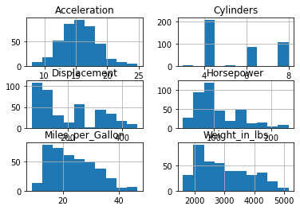

```python
car_df.hist();
```

The figure generated by the hist function uses the default visual settings, and as can be seen, it's quite small. Let's customize the figure for better visual perception.

**Task 2:** Create and modify the histograms.

1. Make the figure larger so that the labels are visible.
2. Change the layout.
3. Change the number of bins to 20.

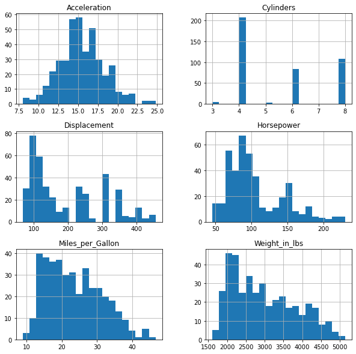

```python
car_df.hist(figsize=(10,10),layout=(3,2),bins=20);
```

A better view-

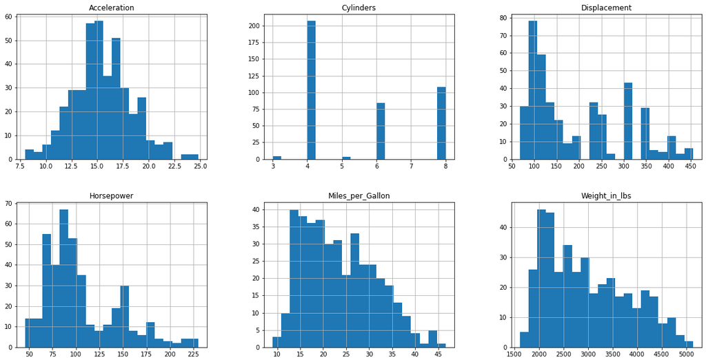

```python
car_df.hist(figsize=(20,10),layout=(2,3),bins=20);
```

As you can see, after changing the figure configurations, all the labels or the entire figure in general is much more perceptible.

## Visual perception experiment

### Perception of length

Lets do a visual perception experiment where we guess the length of a horizontal bar by comparing it with two bars of know lengths.

First, lets import the required libraries and define the lengths of the two bars.

```python
import random
import numpy as np
import time
```

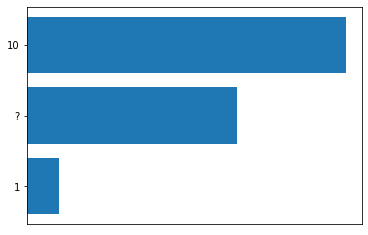

```python
l_short_bar=1
mystery_length=random.uniform(1,10)
l_long_bar=10

plt.barh(np.arange(3), [l_short_bar, mystery_length, l_long_bar], align='center');
plt.yticks(np.arange(3), ('1', '?', '10'));
plt.xticks([]); # no hint!
```

Lets run the experiment once.

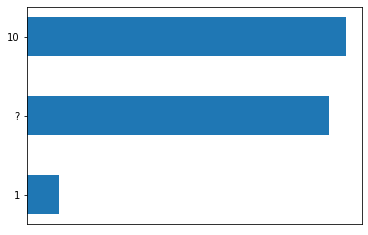

```
Guess the length of the middle bar 9.25
```

```python
perceived_length_list=[]
actual_length_list=[]

def run_exp_once():
    mystery_length = random.uniform(1, 10)  # generate a number between 1 and 10.

    plt.barh(np.arange(3), [l_short_bar, mystery_length, l_long_bar], height=0.5, align='center')
    plt.yticks(np.arange(3), ('1', '?', '10'))
    plt.xticks([]) # no hint!
    plt.show()

    perceived_length_list.append( float(input("Guess the length of the middle bar ")) )
    actual_length_list.append(mystery_length)

run_exp_once()
```

## Task 3. Run the experiment at least TEN times and plot the result.

```
Guess the length of the middle bar
```

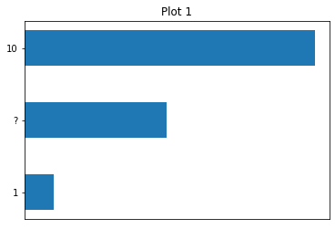

```
Guess 1- 5.2
```

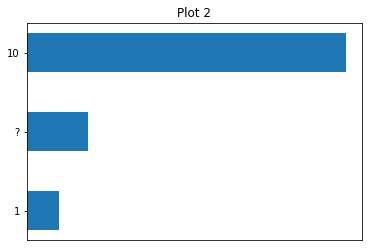

```
Guess 2- 2
```

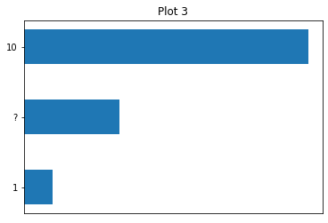

```
Guess 3- 3.1
```

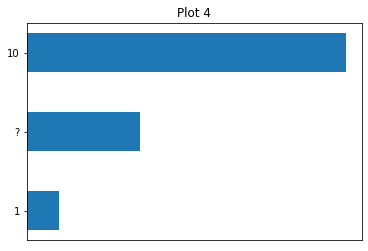

```
Guess 4- 3.9
```

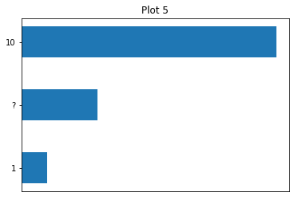

```
Guess 5- 3.4
```

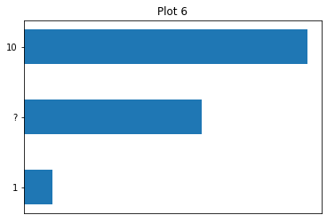

```
Guess 6- 6.8
```

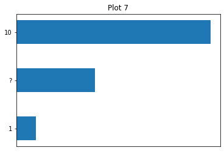

```
Guess 7- 4
```

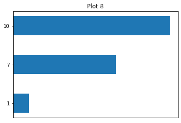

```
Guess 8- 6.75
```

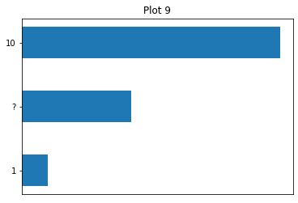

```
Guess 9- 4.3
```

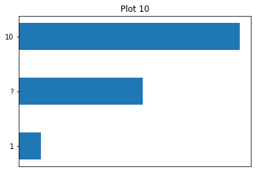

```
Guess 10- 5.75
```

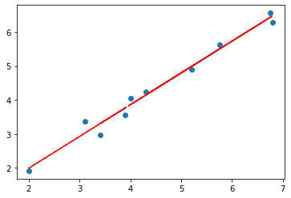

```python
perceived_length_list=[]
actual_length_list=[]
def run_exp_ten():
    print('Guess the length of the middle bar')



    for i in range(1,11): # run 10 times
        mystery_length = random.uniform(1, 10)  # generate a number between 1 and 10.

        plt.barh(np.arange(3), [l_short_bar, mystery_length, l_long_bar], height=0.5, align='center')
        plt.yticks(np.arange(3), ('1', '?', '10'))
        plt.xticks([]) # no hint!
        plt.title(f'Plot {i}')
        plt.show()

        perceived_length_list.append( float(input(f"Guess {i}- ")) )
        actual_length_list.append(mystery_length)


run_exp_ten()

# Start plotting the results
plt.scatter(x=perceived_length_list, y=actual_length_list)
x = perceived_length_list
y = actual_length_list
z = np.polyfit(x, y, 1)
p = np.poly1d(z)

plt.plot(x,p(x),"r--")

plt.show()
```

### Perception of area

Similar to the above experiment, now lets try to predict the area of a circle by comparing it with two circles of know areas.

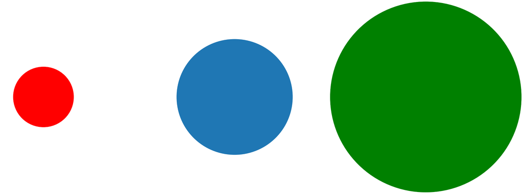

```python
area1 = 0.005
area2 = 0.05

radius1 = np.sqrt(area1/np.pi) # area = pi * r * r
radius2 = np.sqrt(area2/np.pi)
random_radius = np.sqrt(area1*random.uniform(1,10)/np.pi)


plt.axis('equal')
plt.axis('off')
circ1 = plt.Circle( (0,0),radius1,clip_on=False,color='red', label="Area1"); # to change color to red add color = 'red'
circ2 = plt.Circle( (4*radius2,0), radius2, clip_on=False,color='green',label="Area2"); # to change color to green add color = 'green'
rand_circ = plt.Circle((2*radius2,0), random_radius, clip_on=False );

plt.gca().add_artist(circ1); # this adds axes to your circles, without that the circle won't draw
plt.gca().add_artist(circ2);
plt.gca().add_artist(rand_circ);
```

## Run the experiment once

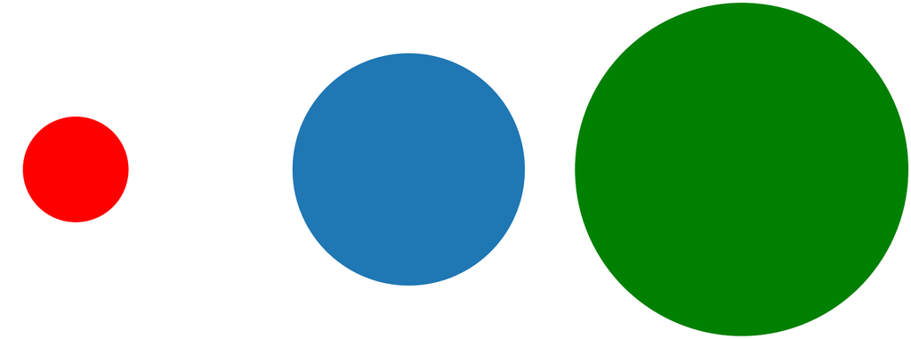

```
Guess the area of the blue circle 5
```

```python
import math
perceived_area_list = []
actual_area_list = []
def run_area_exp_once(n1=0.005, n2=0.05):
    radius1 = np.sqrt(n1/np.pi) # area = pi * r * r
    radius2 = np.sqrt(n2/np.pi)

    mystery_number = random.uniform(1,10)
    random_radius = np.sqrt(n1*mystery_number/math.pi)

    plt.axis('equal')
    plt.axis('off')
    circ1 = plt.Circle((0,0), radius1,clip_on=False,color='red')
    circ2 = plt.Circle((4*radius2,0),radius2,clip_on=False,color='green')
    rand_circ = plt.Circle((2*radius2,0), random_radius, clip_on=False )
    plt.gca().add_artist(circ1)
    plt.gca().add_artist(circ2)
    plt.gca().add_artist(rand_circ)
    plt.show()

    perceived_area_list.append( float(input('Guess the area of the blue circle ')) )
    actual_area_list.append(mystery_number)

run_area_exp_once()
```

## Run the experiment ten times.

### Same colors

```
Guess the area of the blue circle
```

[figure not shown]

```
Guess 1- 9.6
```

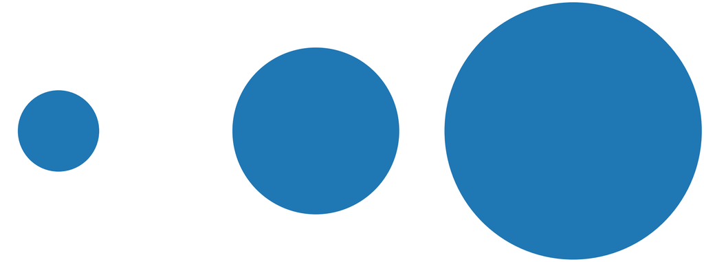

```
Guess 2- 4.75
```

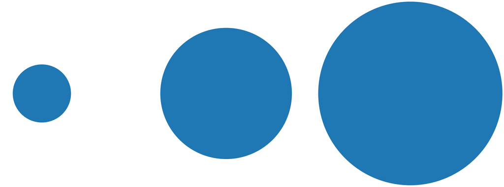

```
Guess 3- 5.1
```

[figure not shown]

```
Guess 4- 6.75
```

[figure not shown]

```
Guess 5- 9.8
```

[figure not shown]

```
Guess 6- 9.6
```

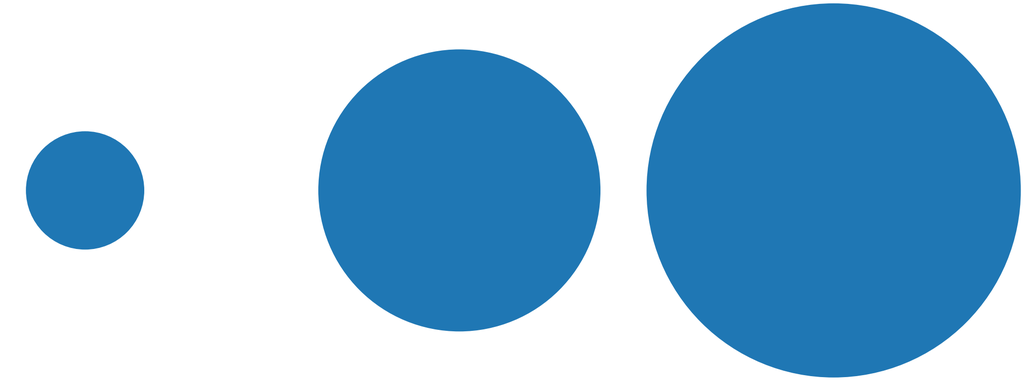

```
Guess 7- 5.75
```

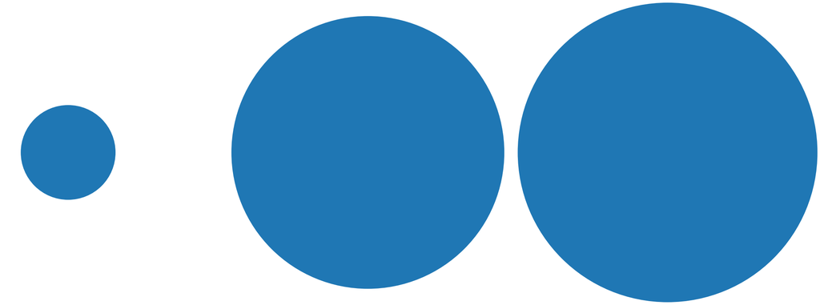

```
Guess 8- 8.75
```

[figure not shown]

```
Guess 9- 9.7
```

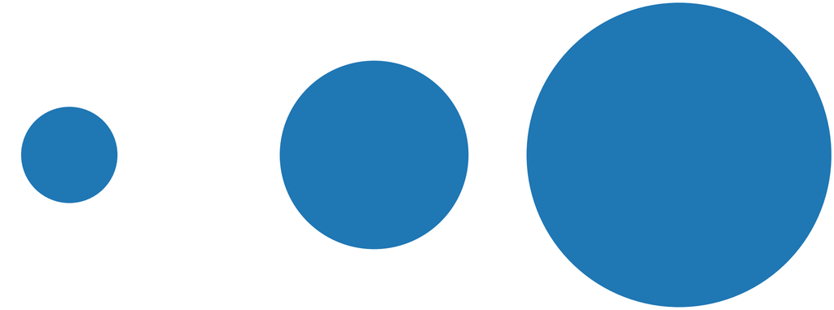

```
Guess 10- 3.75
```

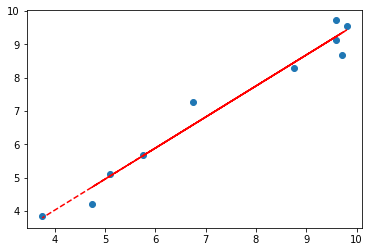

```python
perceived_area_list = []
actual_area_list = []

def run_area_exp(n1=0.005, n2=0.05):
    print('Guess the area of the blue circle')

    for i in range(1,11):

        radius1 = np.sqrt(n1/np.pi) # area = pi * r * r
        radius2 = np.sqrt(n2/np.pi)

        mystery_number = random.uniform(1,10)
        random_radius = np.sqrt(n1*mystery_number/math.pi)

        plt.axis('equal')
        plt.axis('off')


        circ1 = plt.Circle((0,0), radius1,clip_on=False)
        circ2 = plt.Circle((4*radius2,0),radius2,clip_on=False)


        rand_circ = plt.Circle((2*radius2,0), random_radius, clip_on=False )
        plt.gca().add_artist(circ1)
        plt.gca().add_artist(circ2)
        plt.gca().add_artist(rand_circ)
        plt.show()

        perceived_area_list.append( float(input(f'Guess {i}- ')) )
        actual_area_list.append(mystery_number)

run_area_exp()

plt.scatter(x=perceived_area_list, y=actual_area_list)
x = perceived_area_list
y = actual_area_list
z = np.polyfit(x, y, 1)
p = np.poly1d(z)

plt.plot(x,p(x),"r--")

plt.show()
```